# Analyzing the Philippine Stock Exchange Index: An Econometric Approach

A Project in Applied Econometrics Using R

Aries Eroles

August 3, 2024

# 1. Introduction

> A market in which prices always “fully reflect” available information is called “efficient.”

Television channels and shows are produced to weigh on the prices of financial assets every hour of each day. Predictions would be made — on the movement of the stock prices, the stock index, and on whether or not the market is going into the bear or bull market, etc. — and advice would be given on what securities to invest based on their expected performance.

A good number of people seemed to be determined to follow what the market[^1] is doing and where it is going. In the Philippines, the investing public is still minuscule.[^2] But with the financial technology enabling “democratization of finance”, in particular the so-called “GCash effect”, allows users to trade stocks using their e-wallet resulting to an increase in holders of stock broker accounts (Rivas 2024).

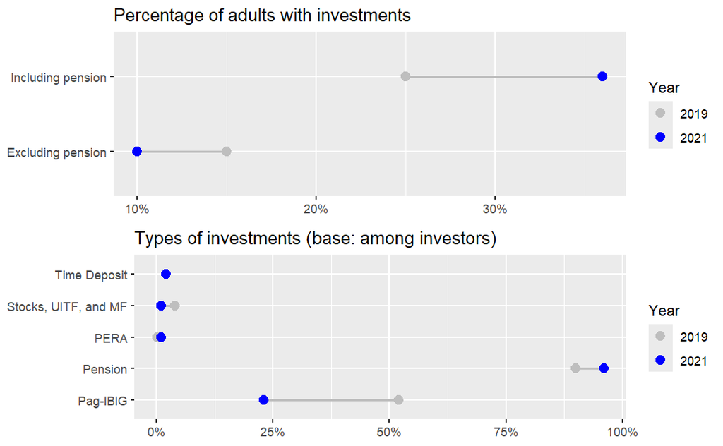

Determining the future prices, or at least their direction, is relevant to the investing public as it is going to determine whether they are going to gain or lose from their investments. By extension, it is important to determine which factor(s) affect the stock price which can be helpful in their investing strategies. Macroeconomic variables seem to be a good candidate as listed companies are part of the macroeconomy and their profitability is affected by the economic conditions. The beta coefficients or the sensitivity of macroeconomic variables to stock prices is one of key elements is in the Arbitrage Pricing Model which was proposed by Stephen Ross in 1976.[^3]

# 2. Statement of the Problem

This paper aims to investigate whether macroeconomic variables determine the market returns of the Philippine Stock Exchange Index (PSEI) and estimate the degree and direction of their relationships using linear regression. A range of variables are included in the study such as national accounts, price indices, exchange rates, as well as indices of other real and financial assets (US equities, gold, and oil). The period of the study covers from the 2005 to 2024 using time series data from the Bangko Sentral ng Pilipinas (BSP), the Philippine Statistics Authority (PSA) and the data repositories of the World Bank (WB), Yahoo Finance, and Federal Reserve Economic Data (FRED) by the Federal Reserve Bank of St. Louis.

In particular, what this paper is trying to answer are the following:

- Which macroeconomic variables can be able to determine the market returns of the Philippine Stock Exchange (PSE) Index? Which ones do not?
- Which of the variables have a positive relationship to PSEI market returns? Which ones have a negative relationship?
- What is the degree of the relationship of the variables with significant explanatory power?

The study is restricted to the returns of the PSEI and does not make inference on the market returns of sub-indices or the returns of the specific listed company in the Philippine Stock Exchange. The model used in this paper is not dynamic in a sense that the order of events of the independent variables is not considered. Such could be significant and may be captured by a more robust analysis using non-linear regression model(S).

# 3. Model Definition

## 3.1. Theoretical background

Fama’s seminal work in 1970 on the Efficient Market Hypothesis (EMH) is the foundation of many studies investigating stock markets (including those related on the relationship to macroeconomic variables).[^4] Fama (1970) declared that an efficient market is the one which prices always “fully reflect” available information. He introduced three forms of market efficiency which priced-in information at various levels:

- *Weak form* - Historical prices are captured in the current price. Market returns, therefore, follows a “random walk”.
- *Semi-strong* - Prices efficiently adjust publicly available information (e.g., annual reports, disclosures, and release of economic data).
- *Strong form* - Prices include private information such as those held by insiders.

In his empirical study which follows, Fama (1981) identifies 1) capital expenditures, 2) average real rate of return on capital, and 3) output having a positive relationship with real stock returns. On the other hand, 4) inflation and 5) real activity in the context of money (i.e., exchange rate and interest rate) are negatively related to returns.

A study by Murcia (2014) found inverse significant relationship between the PSEI and the PHPUSD exchange rate, gold reserve and the Consumer Price Index. The rest of the macroeconomic variables he tested – Wholesale Price Index, Foreign Direct Investment, and Remittance – do not have significant relationships to the index.

In a recent paper by Sajor, Ulla, and Pizarro-Uy (2023), it was found that $\Delta \log$ of Foreign Direct Investment (in Current USD) (including its lagged form – $\Delta \log FDI_{t-1}$) and the real effective exchange rate ($\log RER$) have a positive relationship with the PSE Index in the short run while lagged interest rate ($\Delta INT_{t-3}$) has an inverse relationship with the index. In the long run, RER and INT maintains the direction of their relationship to the index. However, the relationship between the $\log FDI$ and PSEI becomes inverted.

Summary of previous studies

| Study | Dependent Variable | Significant Independent Variables (Direction) |
| --- | --- | --- |
| Fama (1981) | US stock market real returns | * Capital expenditures (+); * Average real rate of return on capital (+); * Output (+); * Inflation (-); * Real activity related to money (-) |
| Murcia (2014) | Philippine Stock Exchange Index (PSEI) | * Philippine Peso - US Dollar exchange rate (PHP = 1 USD) (-); * Gold reserves (-); * Consumer Price Index (CPI) (-) |
| Endres (2020)[^5] | PSEI | In the short run: * PHP = 1 USD (-); * Interest rate ($i$) (+) In the long run: * PHP = 1 USD (+) |
| Sajor, Ulla, and Pizarro-Uy (2023) | PSEI | In the short run: * $\Delta \log FDI$) (+) * $\Delta \log FDI_{t-1}$ (+) * $\log$ of real exchange rate (+) * $\Delta i_{t-3}$ (-) In the long run: * $RER$ (+) * $i$ (-) * $\log FDI$ (-) |

## 3.2. Mathematical model

In this study, a multiple linear regression analysis is employed to measure how the returns of the Philippine Stock Exchange Index respond to the movement of the macroeconomic variables as well as on some financial market indicators. This is mathematically represented by

$$PSEI_r = f(Macro, Fin)$$

where $Macro$ represents the macroeconomic variables while $Fin$ refers to all other financial assets indicators.

In the Arbitrage Pricing Model, the expected returns of the stock market is equal to the risk free rate and the sum of all effects of all relevant factors. Subtracting the risk free rate from both side will give the risk premium equating to the effects of relevant variables.

$$E(R)_i = R_f + \sum_{n=1}^n \beta_n \times F_n + \epsilon$$
$$E(R)_i - R_f = \text{Risk Premium} = \sum_{n=1}^n \beta_n \times F_n +
\epsilon$$

If the Arbitrage Pricing Model is to be employed, the mathematical model can be adjusted to include the risk free rate in the equation similar to the earlier equation.

$$PSEI_r = R_F + \sum_{n=1}^n \beta_n F_n + \epsilon$$

What we can infer from this is that the $R_F$ is, at least, a component of the regression model’s y-intercept.

The variables tested in this study are:

Base Series

| Symbol | Definition, Available Data Range, Source |
| --- | --- |
| NGDP | **Nominal GDP** - Quarterly GDP in current million PHP (1981-2024); (Philippine Statistics Authority 2024) |
| RGDP | **Real GDP** - Quarterly GDP in million PHP at constant 2018 prices (1981-2024); (Philippine Statistics Authority 2024) |
| dNGDP | **Nominal GDP growth rate** - Quarterly year-on-year nominal GDP growth rates in % (1982-2024); (Philippine Statistics Authority 2024) |
| dRGDP | **Real GDP growth rate** - Quarterly year-on-year real GDP growth rates in % (1982-2024); (Philippine Statistics Authority 2024) |
| CPI | **Consumer Price Index** (2018 = 100) (1958-2024); (Bangko Sentral ng Pilipinas 2024f) |
| Inflation | **Inflation rate** - Average monthly year-on-year inflation rates (2018 = 100) in % (1958-2024; (Bangko Sentral ng Pilipinas 2024f) |
| Remittance | **OFW Remittances** - Monthly time series of OFW Remittances in thousands USD (1989-2024); (Bangko Sentral ng Pilipinas 2024d) |
| PHPUSD_Ave | **PHP = 1 USD Exchange Rate** - Monhtly average exchange rate in PHP = 1 USD (1945 - 2024);(Bangko Sentral ng Pilipinas 2024d) |
| PSE | **PSE Index** - Average monthly PSE Index (1995 - 2005)[^6]; \| (Bangko Sentral ng Pilipinas 2024e) \| |
| PSE_Val | Total value of shares traded in a month (in million PHP) (2005 - 2024); (Bangko Sentral ng Pilipinas 2024e) |
| PSE_Vol | Number of shares traded in a month (in millions) (2005 - 2024); (Bangko Sentral ng Pilipinas 2024e) |
| TRRP | **Target RRP** - Monthly average of Bangko Sentral ng Pilipinas Target Reverse Repurchase (RRP) Rate in % (1993 - 2024) ; (Bangko Sentral ng Pilipinas 2024c) |
| IBCL | **Interbank Call Loan Rate** - Monthly Average rate charged between banks for short-term loans (usually overnight) (1993 - 2024); (Bangko Sentral ng Pilipinas 2024c) |
| EER | **Effective Exchange Rate** - Weighted index comparing the Philippine Peso to a basket of currency (1980 = 100) (1993 - 2024); (Bangko Sentral ng Pilipinas 2024c) |
| BRENT | **BRENT Crude Oil Price** - Daily spot prices of BRENT as traded in Europe (1987 - 2024); (FRED, Federal Reserve Bank of St. Louis 2024) |
| SP500 | **S&P 500 Index** - Daily time series of the S&P 500 –an index by Standard & Poor of 500 largest companies listed in the stock exchanges in the US (1957 - 2024); (Yahoo Finance 2024b) |
| GOLD | **COMEX Gold Futures** - Price of Gold Futures as traded in COMEX (2000 - 2024); (Yahoo Finance 2024a) |
| CES | **Consumer Expectations Survey** - Economic outlook of the consumers in the current quarter, next quarter and in the next 12 months (2007 - 2024); Expressed as % positive less % negative sentiment; (B… |
| BES | **Business Expectations Survey** - Economic outlook of the businesses in the current quarter, next quarter and in the next 12 months (2001 - 2004); Expressed as % positive less % negative sentiment; (… |

Derived Series

| Symbol | Definition, Available Data Range, Source |
| --- | --- |
| CPI_MOM | Month-on-month rate of change in CPI - Alternative measure of price changes on month-on-month instead of year-on-year $CPI_{MOM_t} = ( \frac{CPI_t}{CPI_{t-1}} - 1) \times 100);$ \| where $CPI_t$ is th… |
| PHPUSD_dyAve | Year-on-year rate of change between monthly average PHP = 1 USD exchange rate $dy_t = (\frac{PHPUSD_t}{PHPUSD_{t-12}} - 1) \times 100);$ where $dy_t$ is the year-on-year rate of change, $PHPUSD_t$ is … |
| PHPUSD_dmAve | Month-on-month rate of change between monthly average PHP = 1 USD exchange rate $dm_t = (\frac{PHPUSD_t}{PHPUSD_{t-1}} - 1) \times 100);$ where $dm_t$ is the year-on-year rate of change, $PHPUSD_t$ is… |
| PSE_MOM | **PSEI Monthly Returns** - Month-on-month rate of change between monthly average of the PSEI $MOM_t = (\frac{PSE_t}{PSE_{t-1}} - 1) \times 100);$ where $dm_t$ is the year-on-year rate of change, $PSE_… |
| SP500_Ave | Monthly average of S&P 500 |
| SP500_MOM | S&P 500 Monthly Returns - Month-on-month rate of change between monthly average of S&P 500 |
| Gold_Ave | Monthly average of Gold prices |
| Gold_MOM | Gold Monthly Returns - Month-on-month rate of change between monthly average of Gold prices |
| VIX_Ave | Monthly average of the VIX |
| VIX_MOM | Month-on-month rate of change between monthly average of the VIX |
| VIX_YOY | Year-on-year rate of change between monthly average of the VIX |
| VIX_ma12 | 12-month moving average of the VIX |

## 3.3. Dependent and Independent Variables

### PSEI

The main index of the Philippine Stock Exchange (PSEI) grows steadily from 2005 reaching its highest close January of 2018 before falling back to 8,000 level followed by the decline which coincides with the pandemic. The main index suffered its largest monthly drops during the 2007-2008 financial crisis and the recent recession.

In this study, the monthly returns of the PSEI is the dependent variable mainly used but the main index is also tested in the linear regression analysis.

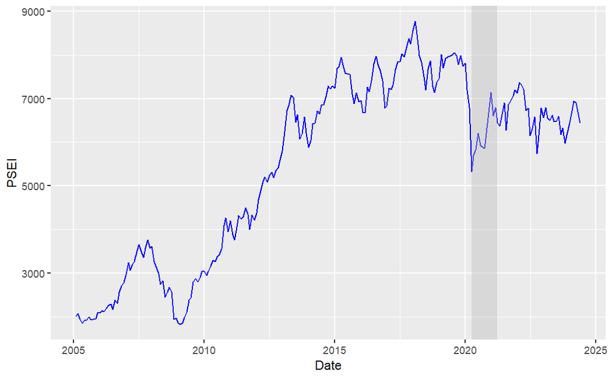

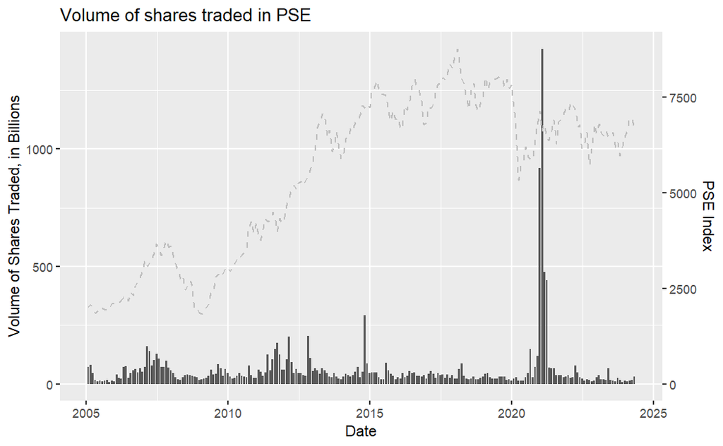

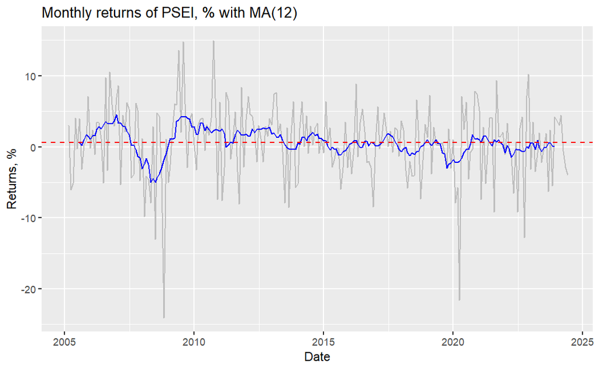

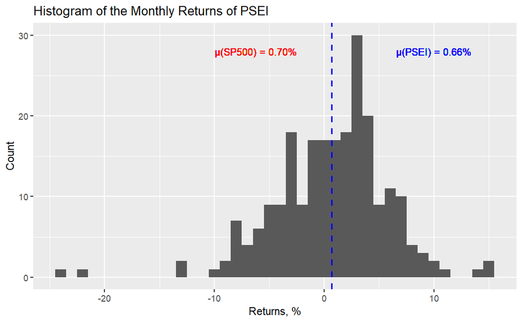

### Gross Domestic Product

It seems to be intuitive that as a common measure of the aggregate economy, the Gross Domestic Product and its movement do affect the stock prices. If, for example, the growing economy is associated with growing dispensable income, a portion of the increased incomes may end up into the capital markets. On the other hand, a growing economy could also mean a growing spending which can be positive to the profitability of firms which potentially leads to increasing stock prices.

But such relationship, if there is any, seems not so obvious as we can see in the scatter plots between GDP growth with the PSEI and its returns. If the outliers from the data is removed, the regression line which is almost a vertical one. A consequence of that is the y-axis (PSE Index or its returns) takes whatever values for a fixed-value of x (growth in real GDP).

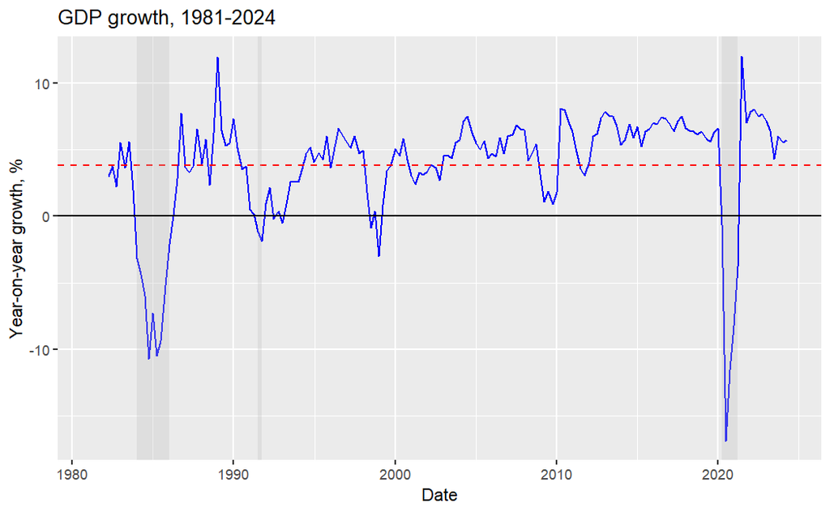

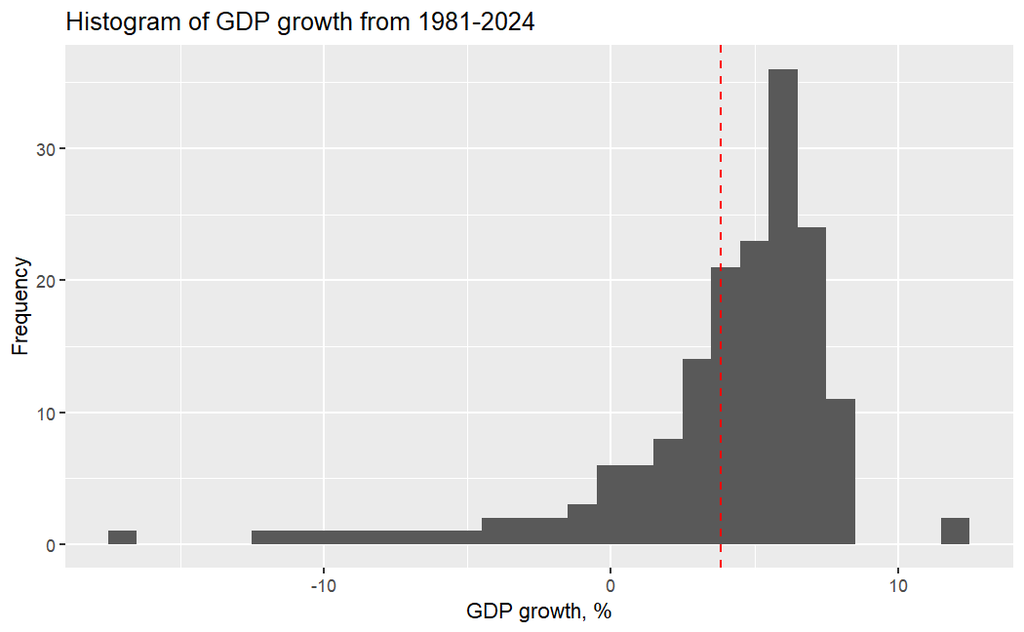

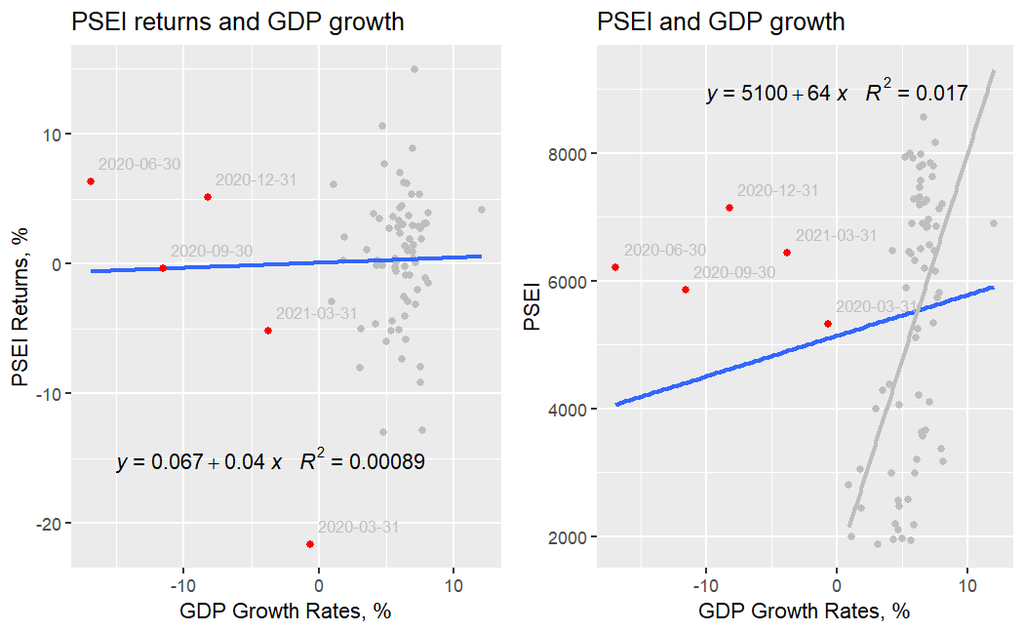

### CPI and Inflation

The movement of input prices may lead firms to adjust their prices which may affect the quantity demanded of their products and services therefore also affecting profits and ultimately to cause movement in their stock prices. Another route of analysis is that inflation affects the disposable income of consumers which could both affect their consumption (which affects the firms profits) and financial investment activities (affecting stock prices).

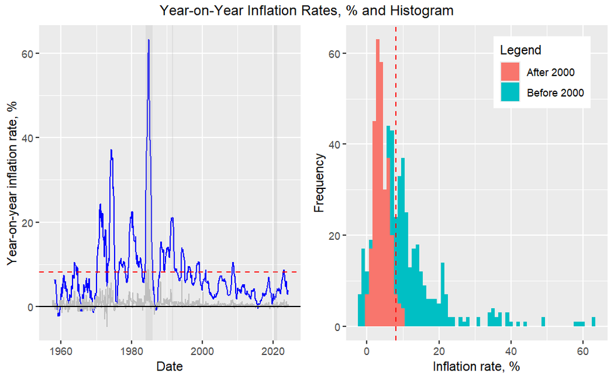

Initial assessment by looking at the scatterplots between the PSEI returns, the CPI and inflations rates seem to show little relations between these variables. But with the main index, especially with the CPI, shows a relatively stronger relationship. However, that is just because the index is in nominal terms and include the effects of prices. Naturally, these two variables should follow similar pattern.[^7]

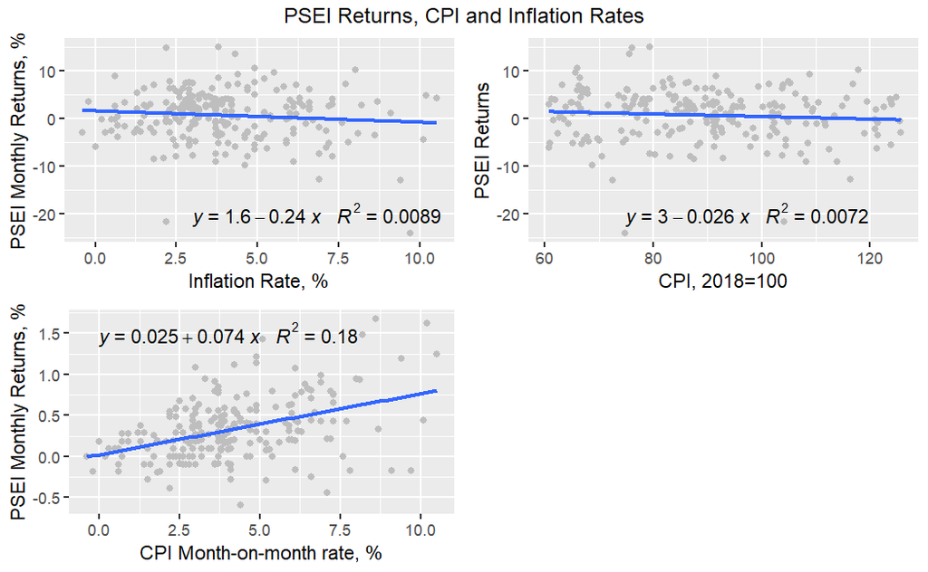

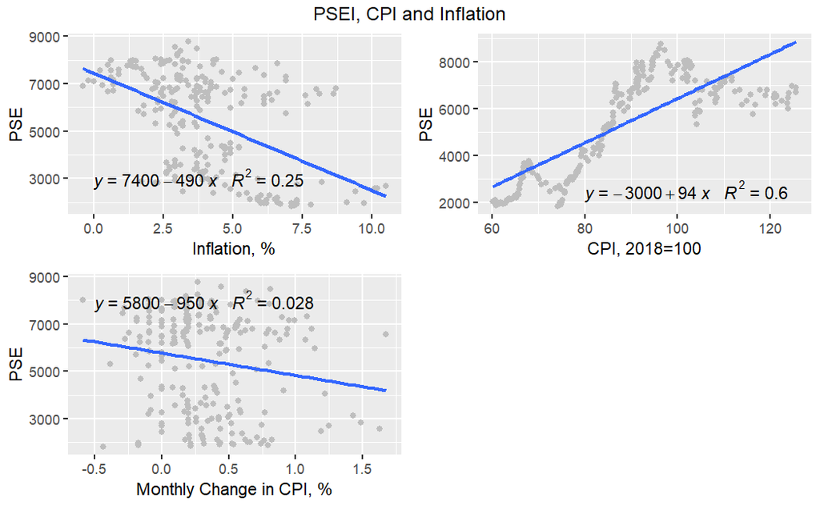

### Remittance

Remittances may have an effect on the stock prices by at least two ways. First is through the increase in spending by the beneficiaries which makes companies profitable. And if not through spending, the second way is through the increase in disposable income which may find its way to the financial markets.

Historical data of remittance growth shows high fluctuations in the 1990s then slowly tapering off in 2010s. Early large fluctuation may be due to the small base effect. Today, remittance growth is relatively less volatile.

Like the CPI and Inflation rates, PSEI growth shows little relationship with remittance growth. When paired with the main index, the coefficient of determination is larger but the negative autocorrelation of the residuals suggests at least one violation of linear regression assumptions.

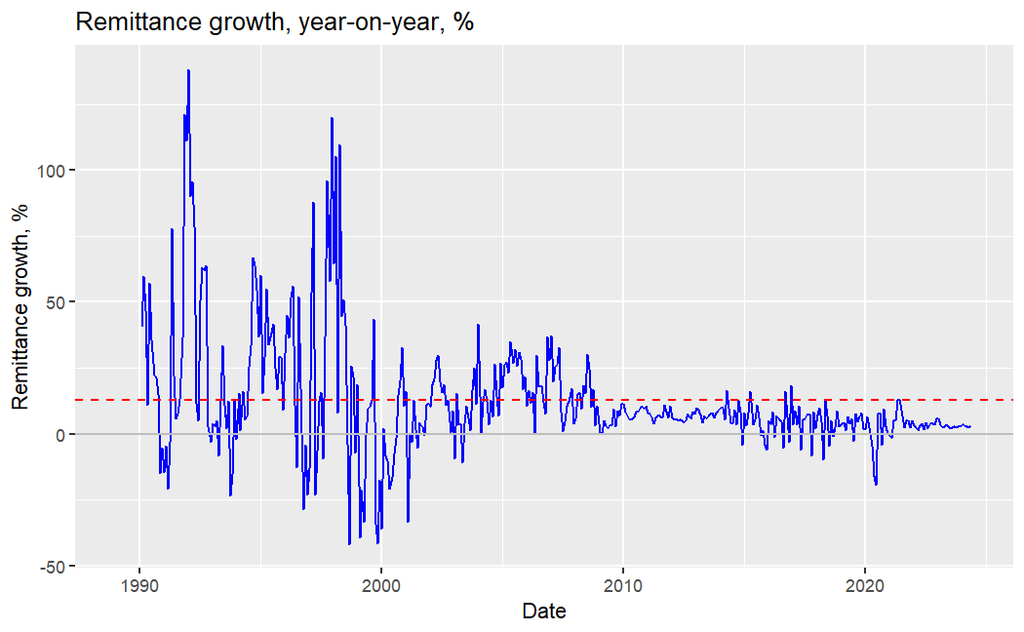

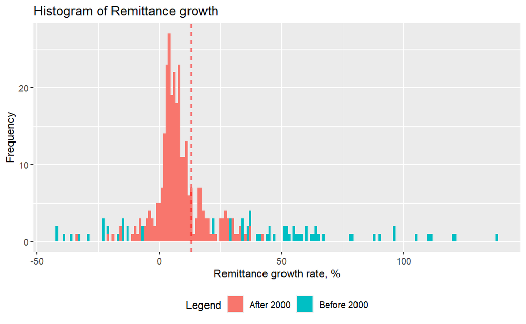

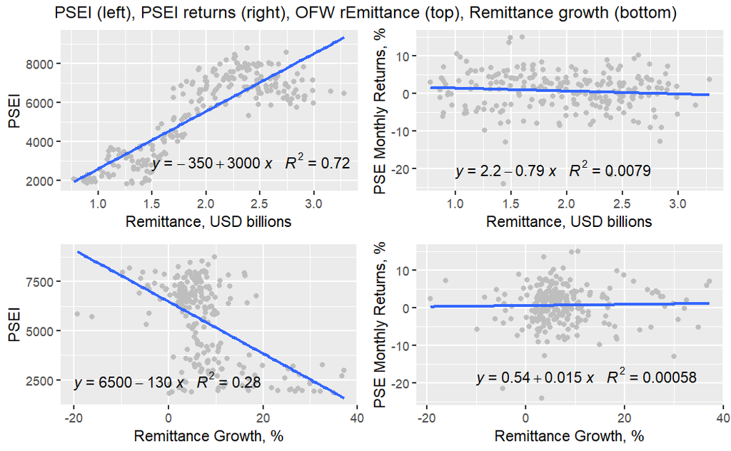

### PHP = 1 USD and EER

The Philippine Peso was for a long time pegged to the US Dollar. At present, the Bangko Sentral ng Pilipinas (BSP) adopted the freely floating exchange rate wherein the determination of the value of Peso to the Dollar (and vice versa) is through the market mechanism.[^8]

Another measure for the foreign exchange is the Effective Exchange Rate (EER) which has a nominal and real indices. The EER is the weighted average exchange rate of the Peso to the currencies of the Philippine major trading partners.

In the scatter plots, only month-on-month changes in the PHP = 1 USD exchange rate to the monthly returns of the PSEI seems a significant relationship, albeit small.

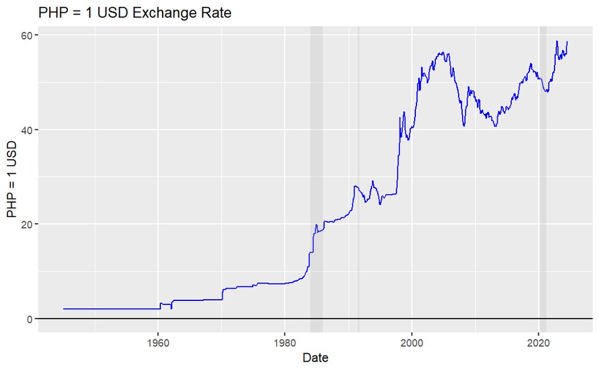

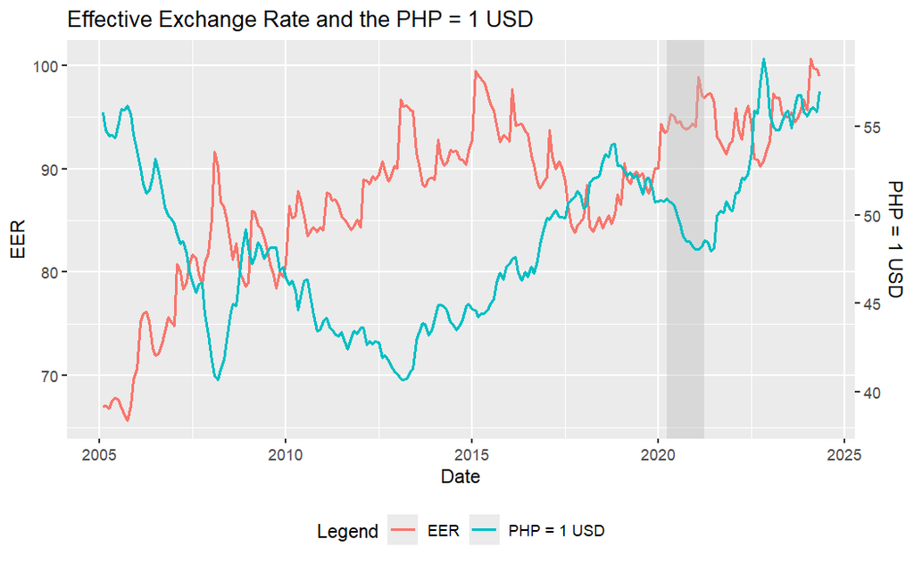

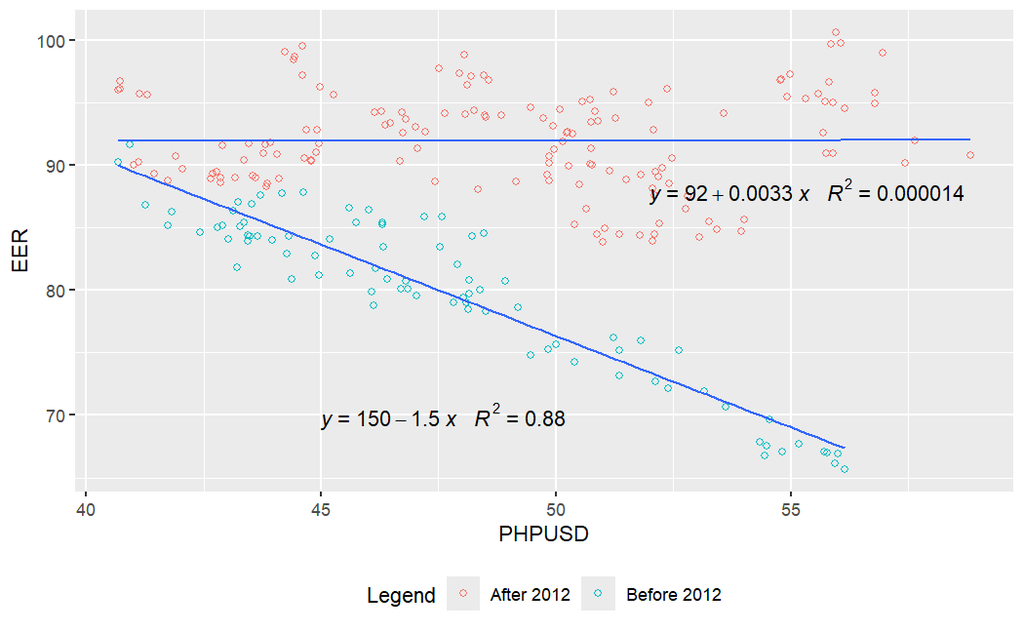

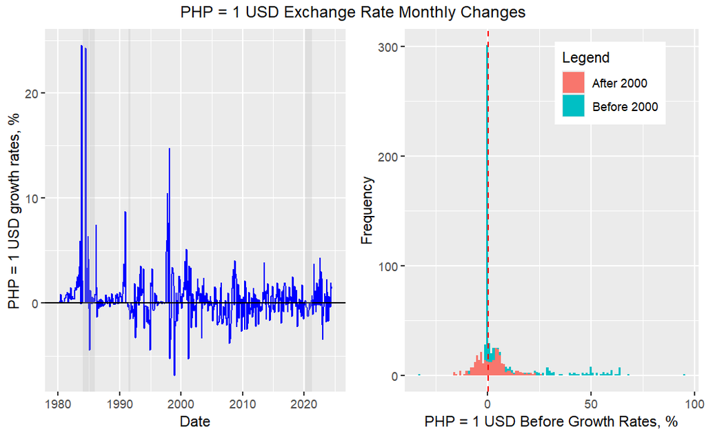

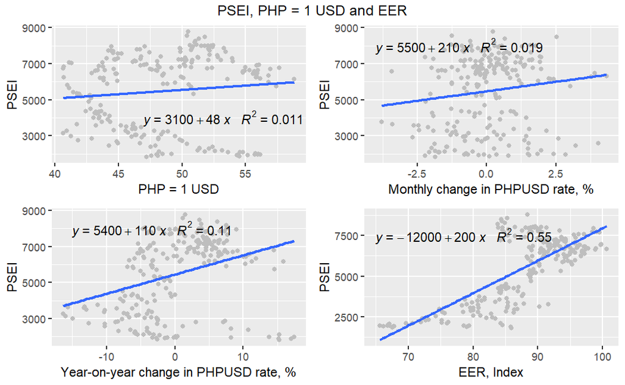

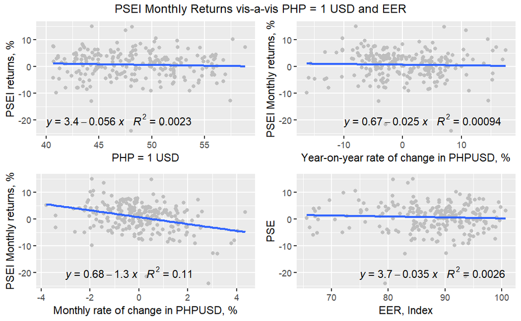

### TRRP, IBCL, and T-Bill

The movement for interest rates, especially with the central bank’s target rate, is one of the most watched indicators in the finance markets. A drop in the interest rate makes credit cheap therefore drives up demand in the financial markets which raises prices of the financial assets. But looking at the scatter plot, the domestic interest rates may not be useful regressors for this paper. It does not mean that there is no relationship between domestic interest rates and stock market returns. But exploring such relationship may require a technique other than linear regression.

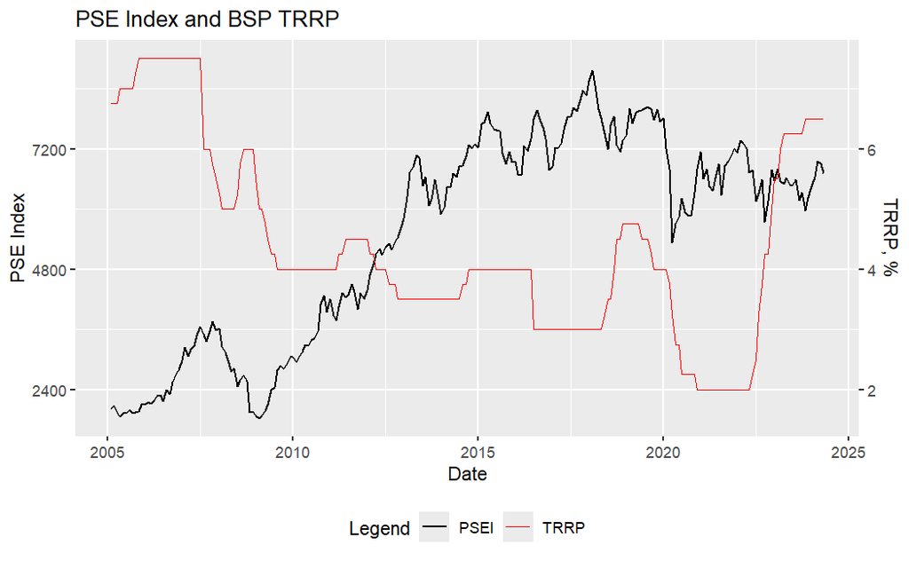

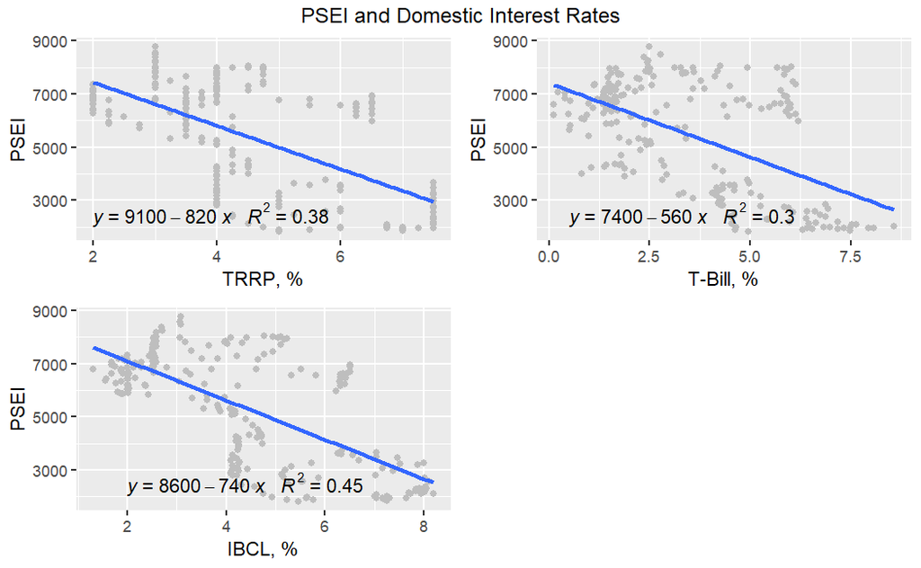

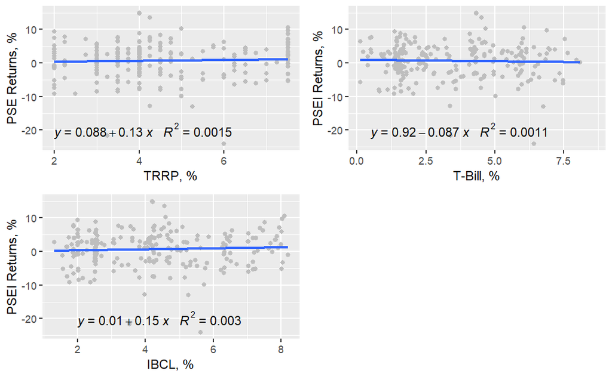

### BRENT

The price of oil is an inflation-driver which makes input prices more expensive which affects the firms profitability. On one hand, oil is also seen as an alternative investment which, when a price of oil rises, funds could flow from the other assets to oil making the prices of the other assets fall.

In the scatter plot, it is only in the monthly growth rates of BRENT with the PSEI returns that have some meaningful relationship, albeit small.

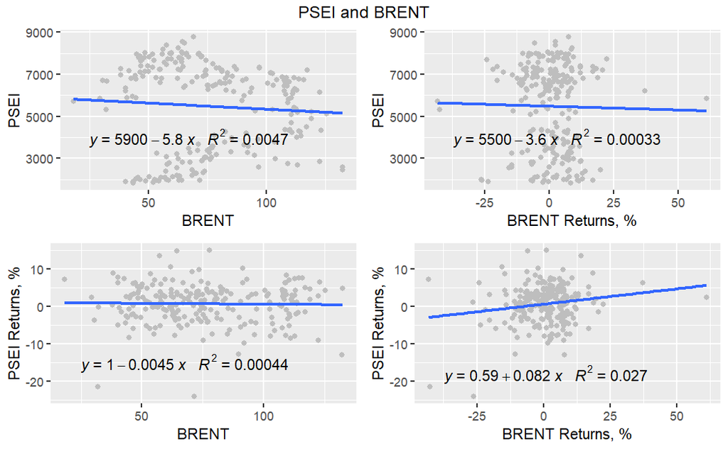

### Gold

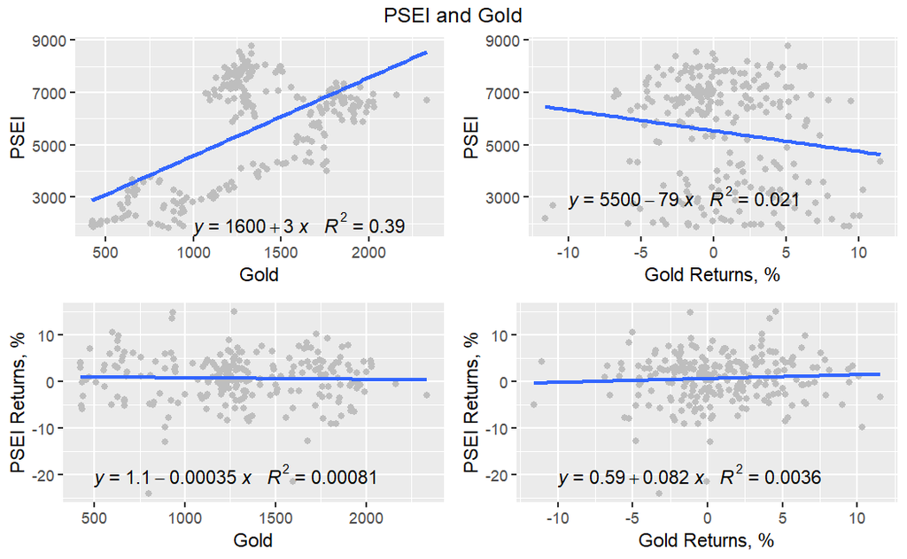

### S&P 500

The S&P 500 can be considered as an alternative investment to the PSEI. If such is the case, an negative relationship is to be expected. But looking at the scatter plot and in the simple linear regression, the result is not what is expected. The variation of S&P500 returns is positively associated with the returns of the PSEI and not a negative one.

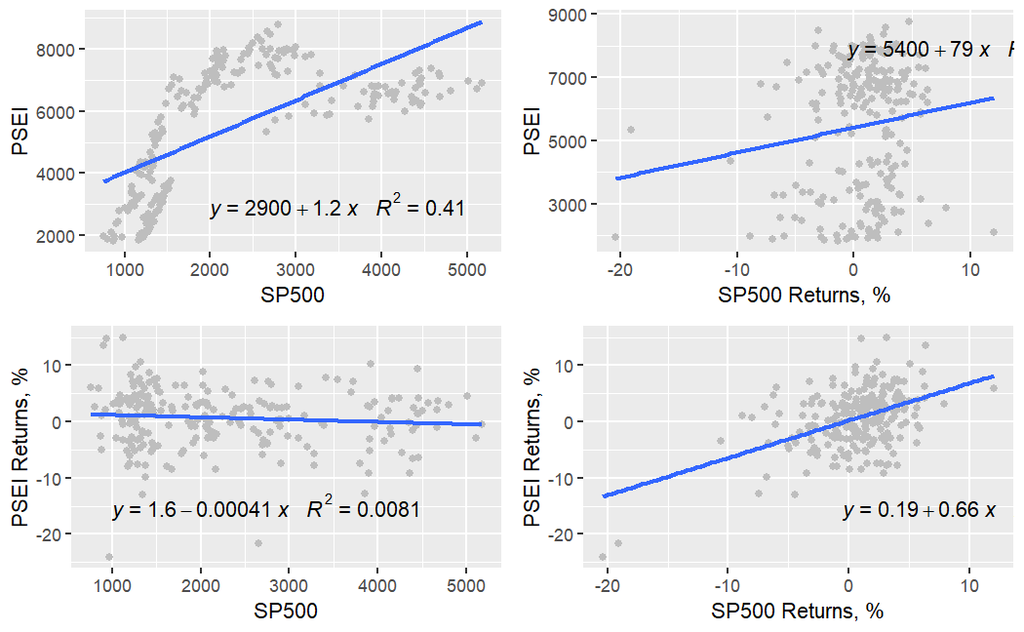

### VIX

The Volatility Index (VIX) is an index developed by the Chicago Board Options Exchange (CBOE) as an attempt to measure the market’s expectations on the S&P 500 based on the derivative markets. An environment of high volatility may result to fall of equity prices as investors rush for exit. A negative relationship therefore is expected which is reflected in the scatter plot.

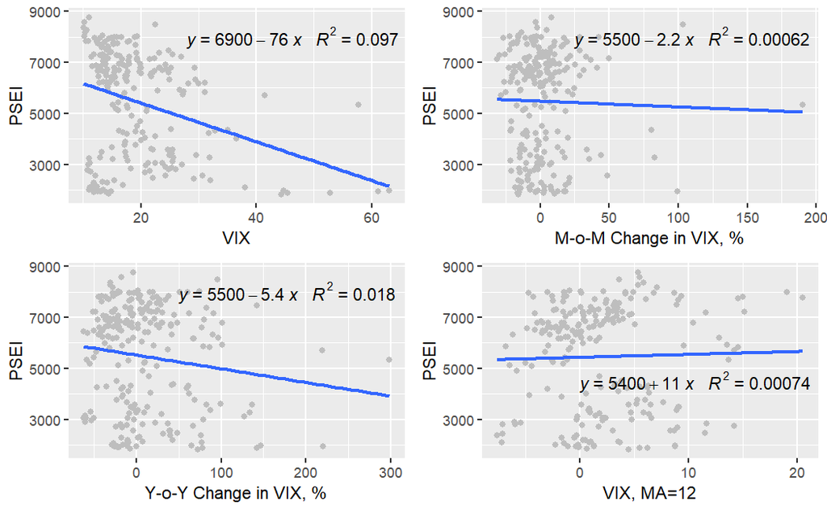

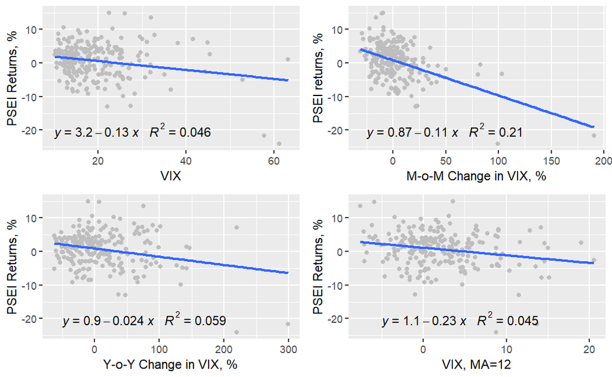

### Correlations

Among the selected variables[^9], the SP500 returns shows “moderate positive correlation” with the PSEI returns while the monthly change in VIX shows “moderate negative correlation”. Among the independent variables, there are notable moderate to high correlations, particularly between inflation and monthly rate of change in CPI, as well as between SP500 returns and monthly rate of change in VIX.

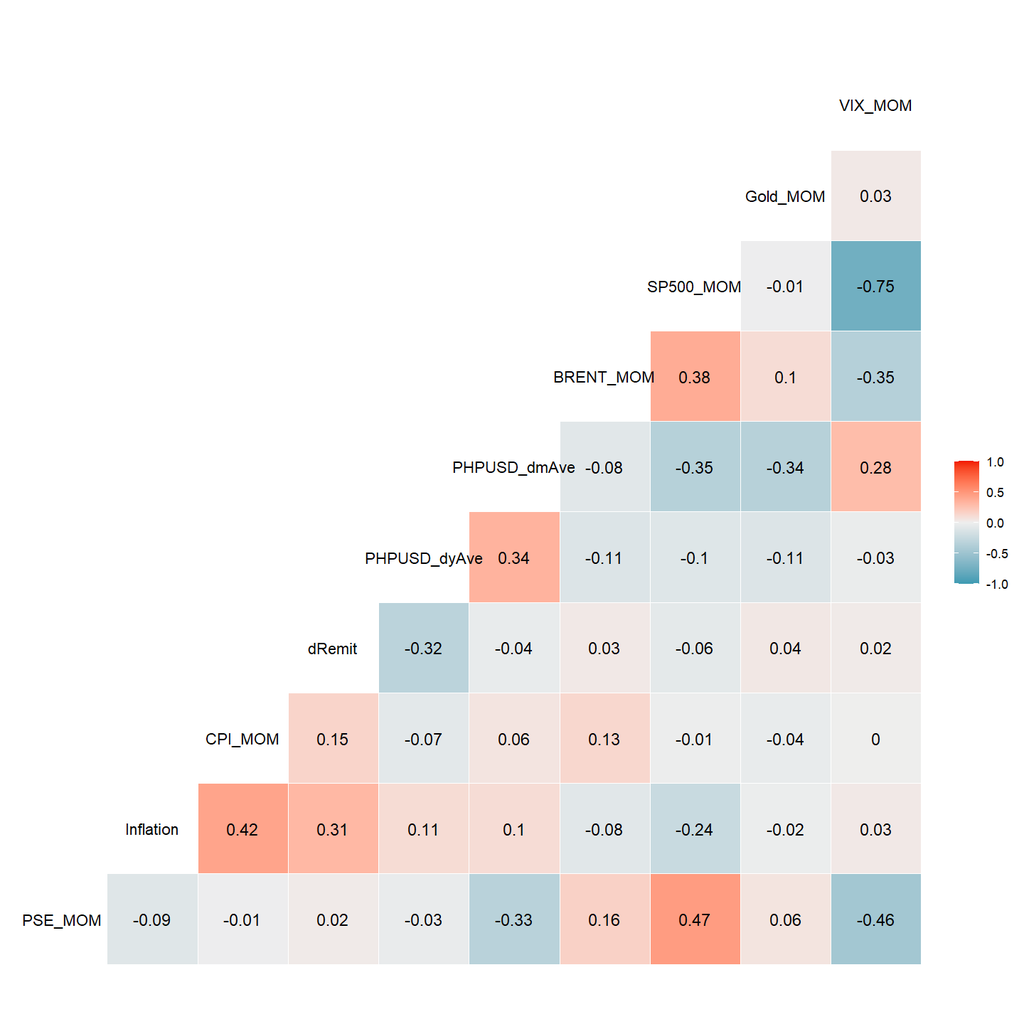

## 3.3. Econometric Model

The econometric model used for this paper is:

$$PSEI_r = \beta_0 + \beta_1F_1 ... + \beta_nF_n + \epsilon$$
where $F$ are the macroeconomic and financial indicators that potentially affects the returns of the PSEI.

When the Arbitrage pricing model is employed, the econometric model is adjusted to:

$$PSEI_r - R_f = \text{Risk Premium} = \beta_0 + \beta_1F_n... + \beta_nFn
+ \epsilon$$

The indepedent variables ($F$), with their expected signs, includes below:

- Inflation, % (-)
- Rate of change in CPI, % (-)
- Rate of change in OFW remittance, % (+)
- Rate of change in PHPUSD exchange rate, % (-)
- Rate of change in oil price (BRENT), % (+)
- SP500 returns, % (+)
- Gold returns, % (+)
- Rate of change in VIX, % (-)

# 4. Regression Analysis

## 4.1. Estimation of Econometric Model

### PSEI returns

Running a linear regression with all of the variables identified the following as significant explanatory variables:

- PHPUSD_dmAve (-)
- SP500_MOM (+)
- VIX_Ave (+)
- VIX_End (-)
- VIX_MOM (-)

Improving from that model, a step-wise regression was dones, which selected the following variables:

- PHPUSD_dmAve(-)
- SP500_MOM(+)
- SP500 Ave(-)
- VIX_ma12(-)
- VIX_MOM(-)

All are independent variables are significant but the regression failed the BP and DW tests. The SP500 and SP500_Ave seem also at odds as there signs are opposite. One possible interpretation is that at high levels of the SP500, investors have incentives to sell PSEI and invest in US equities.

Running a regression for the selected variables in section 3.3, only the following were found to be significant variables:

- PHPUSD_dmAve (-)
- SP500_MOM (+)
- VIX_MOM (-)

```
Call:
lm(formula = PSE_MOM ~ Inflation + CPI_MOM + dRemit + PHPUSD_dmAve +
    BRENT_MOM + SP500_MOM + Gold_MOM + VIX_MOM, data = DATA_merged)

Residuals:
     Min       1Q   Median       3Q      Max
-10.0406  -2.8573   0.4115   2.9750  13.1888

Coefficients:
             Estimate Std. Error t value Pr(>|t|)
(Intercept)   0.69302    0.72336   0.958  0.33908
Inflation    -0.11126    0.17542  -0.634  0.52658
CPI_MOM       0.33775    0.91257   0.370  0.71166
dRemit        0.02915    0.03799   0.767  0.44365
PHPUSD_dmAve -0.68495    0.25569  -2.679  0.00794 **
BRENT_MOM    -0.01678    0.03194  -0.525  0.59981
SP500_MOM     0.30270    0.13502   2.242  0.02596 *
Gold_MOM      0.01522    0.08587   0.177  0.85949
VIX_MOM      -0.05991    0.02056  -2.914  0.00393 **
---
Signif. codes:  0 ‘***’ 0.001 ‘**’ 0.01 ‘*’ 0.05 ‘.’ 0.1 ‘ ’ 1

Residual standard error: 4.518 on 222 degrees of freedom
  (1 observation deleted due to missingness)
Multiple R-squared:  0.2799,    Adjusted R-squared:  0.254
F-statistic: 10.79 on 8 and 222 DF,  p-value: 0.0000000000008344
```

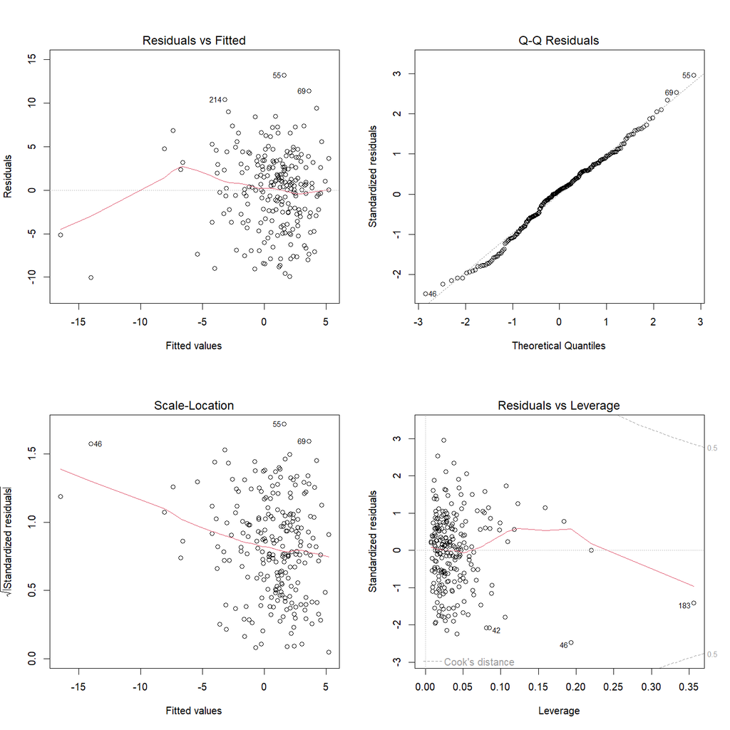

```
   Inflation      CPI_MOM       dRemit PHPUSD_dmAve    BRENT_MOM    SP500_MOM     Gold_MOM
    1.497106     1.277035     1.113127     1.358040     1.270342     2.783324     1.205519
     VIX_MOM
    2.505899

sqrt(VIF)
----------
   Inflation      CPI_MOM       dRemit PHPUSD_dmAve    BRENT_MOM    SP500_MOM     Gold_MOM
    1.223563     1.130060     1.055048     1.165350     1.127095     1.668330     1.097961
     VIX_MOM
    1.583003


    studentized Breusch-Pagan test

data:  model
BP = 15.382, df = 8, p-value = 0.05213


    Durbin-Watson test

data:  model
DW = 2.2388, p-value = 0.09978
alternative hypothesis: true autocorrelation is not 0


    RESET test

data:  model
RESET = 1.247, df1 = 16, df2 = 206, p-value = 0.2349
```

|  | StudRes | Hat | CookD |
| --- | --- | --- | --- |
| 46 | -2.503861227 | 0.19352437 | 0.163280592612 |
| 55 | 3.008447734 | 0.02432944 | 0.024199184213 |
| 69 | 2.566302119 | 0.01609657 | 0.011677815474 |
| 183 | -1.415936830 | 0.35614603 | 0.122666109802 |
| 185 | 0.008508241 | 0.21997739 | 0.000002278602 |

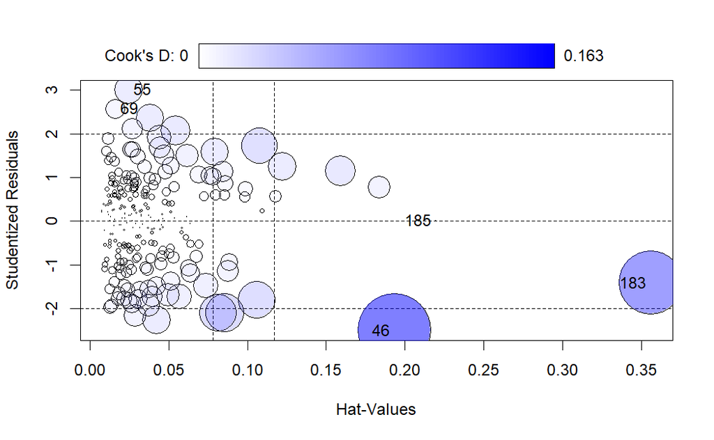

| Date | PSE_MOM | Inflation | CPI_MOM | dRemit | PHPUSD_dmAve | BRENT_MOM | SP500_MOM | Gold_MOM | VIX_MOM |
| --- | --- | --- | --- | --- | --- | --- | --- | --- | --- |
| 2008-10-31 | -24.071761 | 9.7 | -0.17497813 | 3.332255 | 2.8548666 | -26.089268 | -20.395836 | -3.25353964 | 99.19054 |
| 2009-07-31 | 14.780208 | 2.2 | 0.51993068 | 9.309509 | 0.5024496 | -5.992534 | 1.048073 | -1.14554936 | -10.68218 |
| 2010-09-30 | 14.969309 | 3.8 | 0.41459370 | 10.618301 | -1.9228684 | 1.173364 | 3.200607 | 4.56633523 | -9.26379 |
| 2020-03-31 | -21.607240 | 2.2 | -0.38277512 | -4.678432 | 0.3129385 | -42.484569 | -19.068070 | -0.06052665 | 190.19958 |
| 2020-05-31 | 2.423032 | 1.6 | -0.09624639 | -19.307406 | -0.3534056 | 61.175416 | 5.707265 | 1.39878122 | -25.12552 |

```r
PSEIr_select2.lm <- lm(PSE_MOM ~ SP500_MOM + PHPUSD_dmAve + VIX_MOM, data = DATA_merged)

summary(PSEIr_select2.lm)
```

```
Call:
lm(formula = PSE_MOM ~ SP500_MOM + PHPUSD_dmAve + VIX_MOM, data = DATA_merged)

Residuals:
     Min       1Q   Median       3Q      Max
-10.7382  -2.9334   0.3653   3.0882  13.6573

Coefficients:
             Estimate Std. Error t value Pr(>|t|)
(Intercept)   0.56623    0.31802   1.781  0.07633 .
SP500_MOM     0.30947    0.12423   2.491  0.01345 *
PHPUSD_dmAve -0.72208    0.23210  -3.111  0.00210 **
VIX_MOM      -0.05572    0.01950  -2.858  0.00466 **
---
Signif. codes:  0 ‘***’ 0.001 ‘**’ 0.01 ‘*’ 0.05 ‘.’ 0.1 ‘ ’ 1

Residual standard error: 4.478 on 227 degrees of freedom
  (1 observation deleted due to missingness)
Multiple R-squared:  0.2766,    Adjusted R-squared:  0.2671
F-statistic: 28.94 on 3 and 227 DF,  p-value: 0.0000000000000006972
```

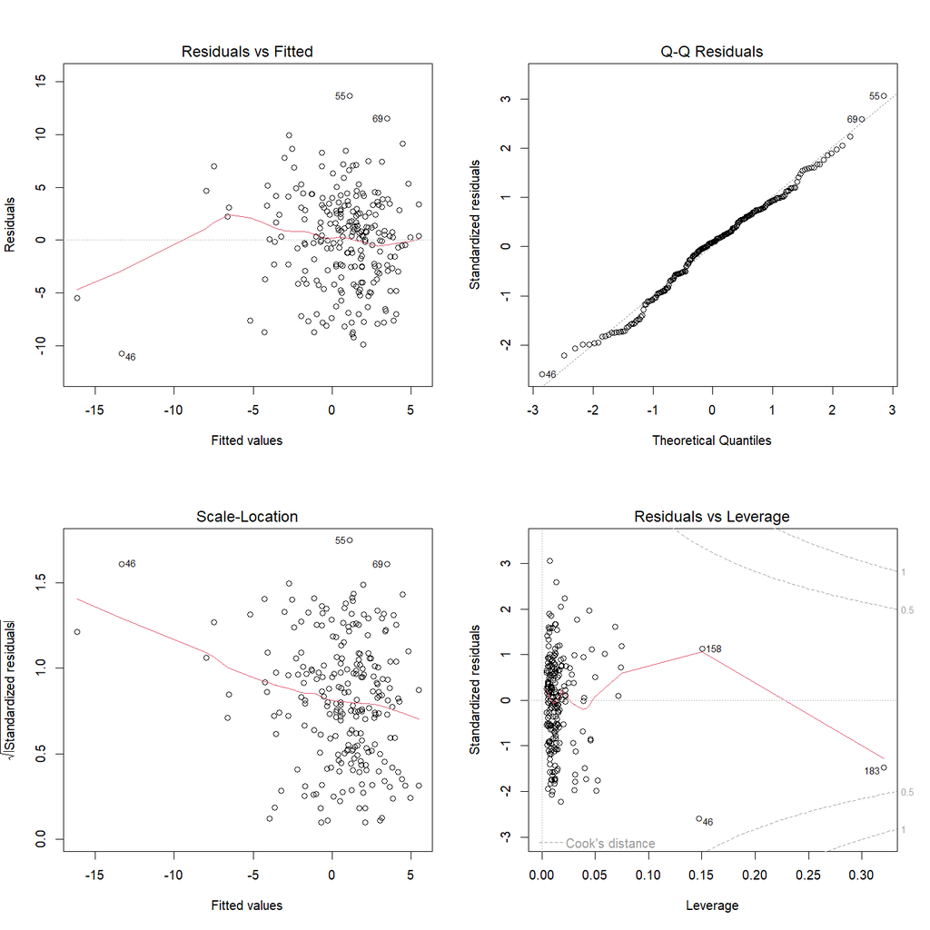

```r
r4abep.plotlm(PSEIr_select2.lm)
```

```r
r4abep.vif(PSEIr_select2.lm) # Good
```

```
   SP500_MOM PHPUSD_dmAve      VIX_MOM
    2.398202     1.139090     2.294802

sqrt(VIF)
----------
   SP500_MOM PHPUSD_dmAve      VIX_MOM
    1.548613     1.067282     1.514860
```

```r
r4abep.bp(PSEIr_select2.lm) # Failed: p-value = 0.03007
```

```
    studentized Breusch-Pagan test

data:  model
BP = 8.9419, df = 3, p-value = 0.03007
```

```r
r4abep.dw(PSEIr_select2.lm) # Good; p-value = 0.06797
```

```
    Durbin-Watson test

data:  model
DW = 2.2459, p-value = 0.06797
alternative hypothesis: true autocorrelation is not 0
```

```r
r4abep.reset(PSEIr_select2.lm) # Failed; p-value = 0.03077
```

```
    RESET test

data:  model
RESET = 2.3692, df1 = 6, df2 = 221, p-value = 0.03077
```

To address the violations of the linear regression assumption, VIX_MOM is squared. The revised regression passed all the diagnostic tests.

```
Call:
lm(formula = PSE_MOM ~ SP500_MOM + PHPUSD_dmAve + I(VIX_MOM^2),
    data = DATA_merged)

Residuals:
   Min     1Q Median     3Q    Max
-9.983 -2.855  0.449  2.978 14.204

Coefficients:
               Estimate Std. Error t value Pr(>|t|)
(Intercept)   0.5924819  0.3180745   1.863 0.063794 .
SP500_MOM     0.4148402  0.0988622   4.196 0.000039 ***
PHPUSD_dmAve -0.8068594  0.2321896  -3.475 0.000612 ***
I(VIX_MOM^2) -0.0003981  0.0001306  -3.047 0.002584 **
---
Signif. codes:  0 ‘***’ 0.001 ‘**’ 0.01 ‘*’ 0.05 ‘.’ 0.1 ‘ ’ 1

Residual standard error: 4.467 on 227 degrees of freedom
  (1 observation deleted due to missingness)
Multiple R-squared:  0.2801,    Adjusted R-squared:  0.2706
F-statistic: 29.44 on 3 and 227 DF,  p-value: 0.0000000000000004092
```

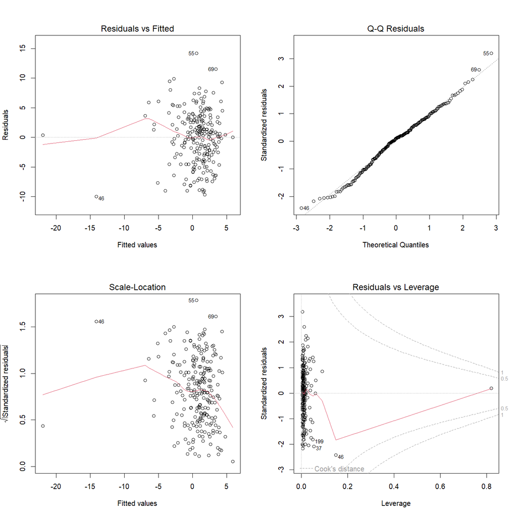

```
   SP500_MOM PHPUSD_dmAve I(VIX_MOM^2)
    1.526085     1.145369     1.357960

sqrt(VIF)
----------
   SP500_MOM PHPUSD_dmAve I(VIX_MOM^2)
    1.235348     1.070219     1.165315


    studentized Breusch-Pagan test

data:  model
BP = 7.1279, df = 3, p-value = 0.06793


    Durbin-Watson test

data:  model
DW = 2.2589, p-value = 0.05375
alternative hypothesis: true autocorrelation is not 0


    RESET test

data:  model
RESET = 1.5121, df1 = 6, df2 = 221, p-value = 0.1752
```

Below are the econometric model which passed the diagnostics:

$$PSEI_r = 0.69 + 0.30 \times SP500_r - 0.11 \times Inflation + 0.34
\times CPI_{dm} + 0.03 dRemit\\
- 0.68 PHPUSD_{dm} - 0.02 BRENT_{dm} + 0.02 Gold_r - 0.06 VIX_{dm} +
\epsilon$$

and

$$PSEI_r = 0.59 + 0.41 \times SP500_r - 0.81 \times PHPUSD_{dm} - 0.0004
\times VIX_{dm}^2 + \epsilon$$

### Risk premium

- Inflation (-)
- SP500 MOM (+)
- VIX_MOM (-)

Improving the initial model using step-wise regression, all of the proposed variables are significant except the PHPUSD_dmAve but fails the diagnostics for BP and RESET tests:

- SP500_MOM (+)
- Inflation (-)
- VIX_MOM (-)
- PHPUSD_dmAve (-)

```
Call:
lm(formula = RP ~ SP500_MOM + Inflation + VIX_MOM + PHPUSD_dmAve,
    data = DATA_merged)

Residuals:
     Min       1Q   Median       3Q      Max
-10.7882  -3.6903   0.0447   3.1226  11.4104

Coefficients:
             Estimate Std. Error t value Pr(>|t|)
(Intercept)  -0.39918    0.76143  -0.524 0.600633
SP500_MOM     0.29909    0.13971   2.141 0.033404 *
Inflation    -0.62293    0.16127  -3.863 0.000148 ***
VIX_MOM      -0.06481    0.02141  -3.027 0.002764 **
PHPUSD_dmAve -0.38891    0.25085  -1.550 0.122498
---
Signif. codes:  0 ‘***’ 0.001 ‘**’ 0.01 ‘*’ 0.05 ‘.’ 0.1 ‘ ’ 1

Residual standard error: 4.777 on 219 degrees of freedom
  (8 observations deleted due to missingness)
Multiple R-squared:  0.3053,    Adjusted R-squared:  0.2926
F-statistic: 24.06 on 4 and 219 DF,  p-value: < 0.00000000000000022
```

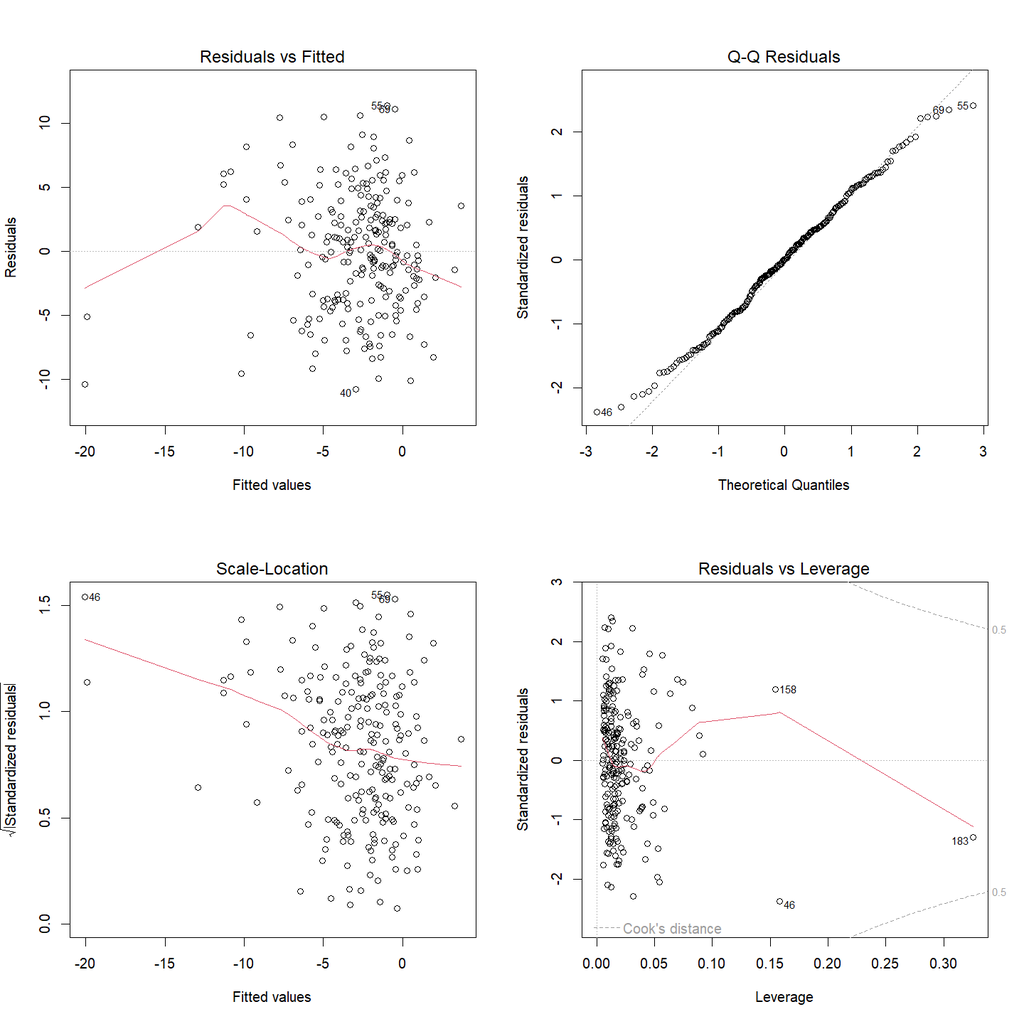

```
   SP500_MOM    Inflation      VIX_MOM PHPUSD_dmAve
    2.644968     1.112922     2.420744     1.139080

sqrt(VIF)
----------
   SP500_MOM    Inflation      VIX_MOM PHPUSD_dmAve
    1.626336     1.054951     1.555874     1.067277


    studentized Breusch-Pagan test

data:  model
BP = 12.128, df = 4, p-value = 0.01643


    Durbin-Watson test

data:  model
DW = 1.9894, p-value = 0.8493
alternative hypothesis: true autocorrelation is not 0


    RESET test

data:  model
RESET = 2.4721, df1 = 8, df2 = 211, p-value = 0.01398
```

Adding back some of the variables and changing the functional form resulted in acceptable diagnostic results but only a handful variables are found to be significant.

- SP500_MOM (+)
- I($Inflation^2$) (-)
- I($\text{VIX_MOM}^2$) (-)
- PHPUSD_dmAve (-)

```
Call:
lm(formula = RP ~ SP500_MOM + I(Inflation^2) + I(VIX_MOM^2) +
    PHPUSD_dmAve + I(dRemit^2) + log(BRENT_Ave) + log(Gold_Ave),
    data = DATA_merged)

Residuals:
     Min       1Q   Median       3Q      Max
-10.7151  -3.2587   0.2286   3.0991  12.5713

Coefficients:
                  Estimate  Std. Error t value Pr(>|t|)
(Intercept)    -11.2492582   8.4329086  -1.334 0.183618
SP500_MOM        0.4094299   0.1120761   3.653 0.000325 ***
I(Inflation^2)  -0.0576719   0.0179777  -3.208 0.001540 **
I(VIX_MOM^2)    -0.0004262   0.0001434  -2.972 0.003297 **
PHPUSD_dmAve    -0.5184311   0.2563154  -2.023 0.044344 *
I(dRemit^2)     -0.0014638   0.0018889  -0.775 0.439196
log(BRENT_Ave)   0.7638606   1.0271792   0.744 0.457897
log(Gold_Ave)    0.9110297   1.1717542   0.777 0.437719
---
Signif. codes:  0 ‘***’ 0.001 ‘**’ 0.01 ‘*’ 0.05 ‘.’ 0.1 ‘ ’ 1

Residual standard error: 4.744 on 216 degrees of freedom
  (8 observations deleted due to missingness)
Multiple R-squared:  0.3243,    Adjusted R-squared:  0.3024
F-statistic: 14.81 on 7 and 216 DF,  p-value: 0.0000000000000009752
```

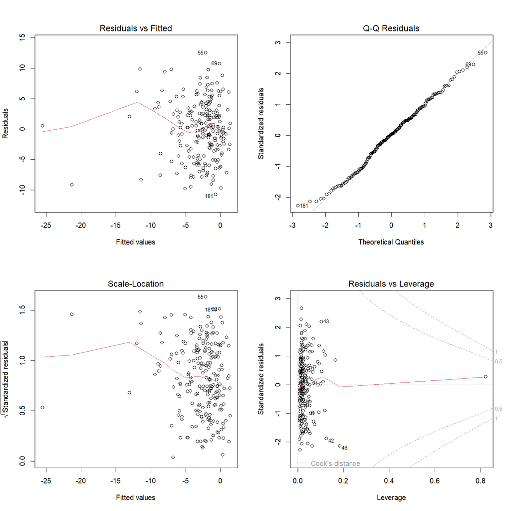

```
     SP500_MOM I(Inflation^2)   I(VIX_MOM^2)   PHPUSD_dmAve    I(dRemit^2) log(BRENT_Ave)
      1.725981       1.345382       1.450443       1.205998       1.813129       1.221862
 log(Gold_Ave)
      2.053298

sqrt(VIF)
----------
     SP500_MOM I(Inflation^2)   I(VIX_MOM^2)   PHPUSD_dmAve    I(dRemit^2) log(BRENT_Ave)
      1.313766       1.159906       1.204344       1.098180       1.346525       1.105379
 log(Gold_Ave)
      1.432933


    studentized Breusch-Pagan test

data:  model
BP = 13.749, df = 7, p-value = 0.05582


    Durbin-Watson test

data:  model
DW = 2.0435, p-value = 0.9476
alternative hypothesis: true autocorrelation is not 0


    RESET test

data:  model
RESET = 1.5677, df1 = 14, df2 = 202, p-value = 0.09078
```

Based on the regression analysis, the econometric model with APM is

$$\text{Risk Premium} = - 11.25 + 0. 409 \times SP500_r - 0.058 \times
Inflation^2 - 0.518 \times PHPUSD_r \\
- 0.001 \times dRemit^2 + 0.764 \times \log(BRENT) + 0.911 \times
\log(Gold)\\
- 0.0004 \times VIX_{dm}^2 + \epsilon$$

which can be re-written as

$$PSEI_r = R_f - 11.25 + 0.409 \times SP500_r - 0.058 \times
\text{Inflation}^2 - 0.518 \times PHPUSD_r \\
- 0.001 \times dRemit^2 + 0.764 \times \log(BRENT) + 0.911 \times
\log(Gold)\\
- 0.0004 \times VIX_{dm}^2 + \epsilon$$

### Quarterly data series

Running a regression on the quarterly data series found that only the CES_CurrentQ as the significant variable with a very small goodness of fit. The sign is also not as expected which may indicate that consumer optimism is likely to go to increased spending and not to increased funds going to the financial markets.

## 4.2. Hypothesis Testing and Validation

Below is the summary of the diagnostics results from the regresion models:

Diagnostic results of the regression models

| Regression model | VIF | BP | DW | RESET |
| --- | --- | --- | --- | --- |
| PSEIr.lm | Passed | Failed | Failed | Failed |
| PSEIr_stepforward.lm | Passed | Failed | Failed | Passed |
| PSEIr_stepbackward.lm | Failed | Failed | Failed | Passed |
| PSEIr_select.lm | Passed | Passed | Passed | Passed |
| PSEIr_select2.lm | Passed | Failed | Passed | Failed |
| PSEIr_select3.lm | Passed | Passed | Passed | Passed |
| RP_select.lm | Passed | Passed | Passed | Passed |
| RP_select2.lm | Passed | Failed | Passed | Failed |
| RP_select3.lm | Passed | Passed | Passed | Passed |

```
=====================================================
                        Dependent variable:
               --------------------------------------
                    PSE_MOM               RP
                 (1)       (2)       (3)       (4)
-----------------------------------------------------
Inflation       -0.111            -0.669***
               (0.175)             (0.187)

CPI_MOM         0.338               0.970
               (0.913)             (0.974)

dRemit          0.029              -0.026
               (0.038)             (0.042)

PHPUSD_dmAve   -0.685** -0.807***  -0.448    -0.518*
               (0.256)   (0.232)   (0.276)   (0.256)

BRENT_MOM       -0.017             -0.006
               (0.032)             (0.035)

I(dRemit2)                                   -0.001
                                             (0.002)

log(BRENT_Ave)                                0.764
                                             (1.027)

log(Gold_Ave)                                 0.911
                                             (1.172)

I(VIX_MOM2)             -0.0004**           -0.0004**
                        (0.0001)            (0.0001)

SP500_MOM       0.303*  0.415***    0.283   0.409***
               (0.135)   (0.099)   (0.144)   (0.112)

Gold_MOM        0.015              -0.032
               (0.086)             (0.093)

VIX_MOM        -0.060**           -0.066**
               (0.021)             (0.022)

I(Inflation2)                               -0.058**
                                             (0.018)

Constant        0.693     0.592    -0.284    -11.249
               (0.723)   (0.318)   (0.777)   (8.433)

-----------------------------------------------------
AIC             1363.1   1353.05   1349.62   1342.99
BIC            1397.52   1370.26   1383.74   1373.7
R2              0.280     0.280     0.310     0.324
Adjusted R2     0.254     0.271     0.285     0.302
=====================================================
Note:                   *p<0.05; **p<0.01; ***p<0.001
```

## 4.3. Forecasting and Prediction

Recalling the econometric model for the PSEI returns, the relationship between the changes in the independent variables and the expected monthly returns to the PSEI are as follows:

$$PSEI_r = 0.59 + 0.41 \times SP500_r - 0.81 \times PHPUSD_{dm} - 0.0004
\times VIX_{dm}^2 + \epsilon$$

- a percentage increase (decrease) in the the SP500 will result to 0.41 percentage increase (decrease) of the PSEI returns;
- a percentage increase(decrease) of PHP = 1 USD rate will result to a 0.81 percentage decrease (increase) of the PSEI returns; and
- a percentage increase of the VIX index squared results to a 0.04 (0.0004%) basis points decrease (increase) of the PSEI returns.

For the significant variables of the model using the Arbitrage Pricing framework:

$$PSEI_r = R_f - 11.25 + 0.409 \times SP500_r - 0.058 \times
\text{Inflation}^2 - 0.518 \times PHPUSD_r \\
- 0.001 \times dRemit^2 + 0.764 \times \log(BRENT) + 0.911 \times
\log(Gold)\\
- 0.0004 \times VIX_{dm}^2 + \epsilon$$

- a percentage increase (decrease) in the the SP500 will result to 0.409 percentage increase (decrease) of the PSEI returns;
- a percentage increase (decrease) of inflation squared will induce a 0.058 percentage decrease (increase) in the PSEI returns;
- a percentage increase (decrease) of the VIX index squared will induce a 0.04 (0.0004%) basis point decrease (increase) of the PSEI returns; and
- a percentage increase(decrease) of PHP = 1 USD rate will result to a 0.518 percentage decrease (increase) of the PSEI returns.

The following insignificant variables that are nevertheless in the model:

- a percentage increase (decrease) of remittance will result to a 0.1 basis point decrease (increase) in the PSEI returns;
- a percentage increase (decrease) of crude oil price will induce to a 0.764 increase (decrease) in returns; and
- a percentage increase (decrease) in the price of gold will induce to a 0.911 increase (decrease) in returns.

As an illustration, if the SP500 is expected to increase by 2.5% next month, the PHP = 1 USD rate will increase by 0.68%, Gold price will not be changing, while VIX is expected to dissipate by 5%. With those assumptions, PSEI is expected to grow by 1.07%.[^10]

Supposed that, in addition to the aforementioned assumptions, the following variables are to be expected next month:

- Risk free rate = 6.3%;
- Inflation rate = 3.5%;
- OFW remmittance growth = 1%;
- Price of oil = $80; and
- Price of gold = $2,385.7.

The value the regression model will give is -0.9[^11], which, when added to the risk free rate is equal to 5.4%.[^12]

# 5. Application and Recommendations

## 5.1. Model Applications

In reference to the research questions asked earlier, it is the SP500 which has a positive relationship with the PSEI returns. Inflation, the PHP = 1 USD exchange rate, and the rate of change of VIX all have negative relationship with the latter.

Those found to have no significant relationship with the returns of the PSEI are the growth of the remittance and the prices of oil and gold.

Considering the significant variables, it is perhaps the forex rate which has some practical applications. Given that SP500 has a positive $\beta$, it is not therefore a counter-cyclical for PSEI. And VIX, given that is determined using the prices of options for the SP500, would certainly affects US equities.

## 5.2. Recommendations

The study is limited on the linear regression relationship between macroeconomic variables and financial indicators with the main index of the PSE. Given an $R^2$ of 0.25 to 0.30, the model could only explain a quarter of the variation of the PSEI returns.

It could be argued that a lot of what was left unexplained are idiosyncrasies. But, more often than not, we would hear from the news on movements in the stock market having to do with events in the macroeconomy. Usually, they are just even announcements, or sometimes in anticipation, and still sometimes, as a counter-reaction to better-than-expected (or worse-than-expected) statistics. We all know how the stock market can be volatile. Models like the ones presented in this paper is not that very helpful in trading especially with high-frequency trading induced by supercomputers.

A better model suited for the dynamic nature of stock markets returns is needed. It should capture the change in behavior when an event is expected, the actual event, and what happened after some period. The model is expected to be non-linear. And it should also incorporates shifts of the curve(s).

However, if limited to understanding the linear relationship between the variables, one way to further improve the study is by analyzing for each sub-index of the PSEI. Perhaps that has a more practical use in determining which among the sub-index moves in the opposite direction.

# References

Bangko Sentral ng Pilipinas. 2018. “2018 Consumer Finance Survey: A Snapshot of the Philippine Household Finances.”

———. 2021. “2021 Final Inclusion Survey.”

———. 2024a. “Business Expectations Survey.” https://www.bsp.gov.ph/SitePages/MediaAndResearch/Business%20Expectations%20Report.aspx.

———. 2024b. “Consumer Expectations Survey.” https://www.bsp.gov.ph/SitePages/MediaAndResearch/ConsumerExpectationSurvey.aspx.

———. 2024c. “Financial System Accounts.” https://www.bsp.gov.ph/SitePages/Statistics/Financial%20System%20Accounts.aspx?TabId=14.

———. 2024d. “Statistics - External Accounts.” https://www.bsp.gov.ph/SitePages/Statistics/External.aspx?TabId=8.

———. 2024e. “Statistics - Other Real Sector Accounts.” https://www.bsp.gov.ph/SitePages/Statistics/OtherRealSectorAccounts.aspx?TabId=7.

———. 2024f. “Statistics - Prices.” https://www.bsp.gov.ph/SitePages/Statistics/Prices.aspx?TabId=1.

Endres, Erick John E. 2020. “Impact of Macroeconomic Factors on Stock Market: Empirical Evidence from the Philippines.” *International Journal of Research Publication* 50 (1): 114–25.

Erick John E. Endres. 2020. “Impact of Macroeconomic Factors on Stock Market: Empirical Evidence from the Philippines.” *International Journal of Research Publication* 50 (1): 114–25.

Fama, Eugene F. 1970. “Efficient Capital Markets: A Review of Theory and Empirical Work.” *The Journal of Finance*, Papers and proceedings of the twenty-eighth annual meeting of the american finance association, 25 (2): 383–417. https://www.jstor.org/stable/2325486.

———. 1981. “Stock Returns, Real Activity, Inflation, and Money.” *The American Economic Review* 71 (4): 545–65. https://www.jstor.org/stable/1806180.

FRED, Federal Reserve Bank of St. Louis. 2024. “Crude Oil Prices: Brent - Europe [DCOILBRENTEU].” https://fred.stlouisfed.org/series/DCOILBRENTEU.

Murcia, John Vianne B. 2014. “Macroeconomic Estimation of Selected Philippine Stock Market Indices.” *Southeast Asian Interdisciplinary Research Journal* 2 (1): 10–18.

Philippine Statistics Authority. 2024. “Quarterly Gross Domestic Product Series,” May. https://psa.gov.ph/sites/default/files/nap/Quarter-Q1-1981-to-Q1-2024_May2024_0.xlsx.

Rivas, Ralf. 2024. “The GCash Effect: More Middle-Income Earners Join Stock Market.” *Rappler*, May. https://www.rappler.com/business/philippine-stock-exchange-market-investor-profile-report-2023/.

Sajor, Benedict, Aelijohn Ulla, and Anna Corrina Pizarro-Uy. 2023. “Impact of Macroeconomic Variables on Stock Market Price Levels: Evidence from the Philippines.” *Journal of Economics, Finance and Accounting Studies* 5 (2): 116–38. https://doi.org/10.32996/jefas.

Yahoo Finance. 2024a. “Gold Aug 24 (GC=f).” https://finance.yahoo.com/quote/GC=F/.

———. 2024b. “S&p 500 (^GSPC).” https://finance.yahoo.com/quote/%5EGSPC/.

1. When market is mentioned in this paper, it refers to the financial capital market, specifically, the stock market, otherwise specified.
2. The 2021 Financial Inclusion Survey (FIS) conducted by the Bangko Sentral ng Pilipinas indicates that only 36% of the adult population has investments including pension (10% if pension is excluded), of which, only 1% invested in stocks, mutual funds and unit trust investment funds (UITF). The 2018 Consumer Finance Survey also yield similar dismal participation of Filipino households in the stock market with 0.3% households indicate they have MF and/or UITF, 0.1 % with listed stocks holdings, and 0.1% indicated they have fixed income holdings. (Bangko Sentral ng Pilipinas 2018) (Bangko Sentral ng Pilipinas 2021)
3. In Arbitrage Pricing Model (APM), the expected market returns of an asset is equal to the sum of risk-free rate of the return and the various factors which influenced the market returns (such as macroeconomic variables) multiplied by the sensitivity of the asset returns or its beta ($\beta$).
4. Eugene Fama won the Nobel Prize in Economics in 2013 for his Efficient Market Hypothesis and the empirical studies he made on asset prices (together with two economists who also studies asset pricing – Robert Shiller and Lars Peter Hansen).
5. Erick John E. Endres (2020) employed Autoregressive Distributed Lag (ARDL) model to test for the short run while F-Bounds and Wald Tests were used for the long run.
6. The Philippine Stock Exchange changed its methodology to the main index in 1995.
7. Durbin-Watson test for the linear regression with PSE ~ CPI yields a DW = 0.06 suggesting an evidence of positive autocorrelation. Also, in the Fisher Equation $(1 + i) = (1 + r ) \times (1 + \pi)$, which is for very small numbers approximated to $i = r + \pi$ describing the relationship between nominal and real interest rates and inflation.
8. Specifically through the interbank foreign exchange market.
9. Included are the variables which passed the ADF test for stationarity.
10. With a lower bound of 0.3% and an upper bound of 1.8%.
11. With a lowerbound of -2.2 and an upper bound of 0.5.
12. Lower bound is 4.1% while the upper bound is 6.8%.